# 1_259195_Piotr_Jasiński

## LABORATORIUM 1 - REGRESJA LINIOWA

## 1.1 Porównanie analitycznej i numerycznej implementacji regresji na syntetycznym zbiorze

```python
import numpy as np
from sklearn.datasets import make_regression
from scipy.optimize import minimize
import matplotlib.pyplot as plt
import time
```

```python
X, y = make_regression(n_samples=2595, n_features=1, noise=16, random_state=95)
X = X.flatten()
```

**Funkcja analityczna** regresji liniowej:

```python
def analytical_lr(X, y):
    X_bias = np.vstack([X, np.ones(len(X))]).T  # Dodajemy jedynki (wyrazy wolne)

    w = np.linalg.inv(X_bias.T @ X_bias) @ X_bias.T @ y ## funkcja wyznaczająca macierz odwrotną
    return w[0], w[1]  # a, b (slope / intercept)
```

**Funkcja numeryczna** regresji liniowej oraz wykorzystywana w niej funkcja błędu MSE (średniokwadratowego)

```python
def mse(w, X, y):
    X_bias = np.vstack([X, np.ones(len(X))]).T
    results = X_bias @ w
    return np.sum((y - results) ** 2) / len(y)

def numerical_lr(X, y):
    w0 = np.ones(2)  # Początkowe wagi
    result = minimize(mse, w0, args=(X, y), method='Powell')
    return result.x[0], result.x[1]
```

**Funkcja predykcji** - do generowania wyniku na podstawie nachylenia i wyrazu wolnego funkcji:

```python
def predict(X, slope, intercept):
    return slope * X + intercept
```

**Obliczenia** - wyniki parametrów dla obu metod oraz ich predykcje wyników:

```python
start = time.time()
for _ in range(100):
    a1, b1 = analytical_lr(X, y)
end = time.time()
alr_time = end - start

start = time.time()
for _ in range(100):
    a2, b2 = numerical_lr(X, y)
end = time.time()
nlr_time = end - start

print(f"Metoda analityczna: slope: {a1}, intercept: {b1}")
print(f"Czas wykonania metody analitycznej: {alr_time:.8f} s.")
print(f"Metoda numeryczna: slope: {a2}, intercept: {b2}")
print(f"Czas wykonania metody numerycznej: {nlr_time:.8f} s.")


alr_predictions = predict(X, a1, b1)
nlr_predictions = predict(X, a2, b2)

mse_analytical = np.mean((y - alr_predictions) ** 2)
mse_numerical = np.mean((y - nlr_predictions) ** 2)
print(f"Błąd średniokwadratowy dla metody analitycznej: {mse_analytical}")
print(f"Błąd średniokwadratowy dla metody numerycznej: {mse_numerical}")
```

```
Metoda analityczna: slope: 86.01154366068859, intercept: 0.4956823911892464
Czas wykonania metody analitycznej: 0.02199340 s.
Metoda numeryczna: slope: 86.01154953300356, intercept: 0.49568252078714303
Czas wykonania metody numerycznej: 0.30120230 s.
Błąd średniokwadratowy dla metody analitycznej: 261.93076596252337
Błąd średniokwadratowy dla metody numerycznej: 261.9307659625565
```

Można zauważyć, że wynikowe parametry funkcji liniowej są bardzo podobne, a błąd średniokwadratowy dla obu funkcji wychodzi ten sam.

#### Wizualizacja wyników i porównanie

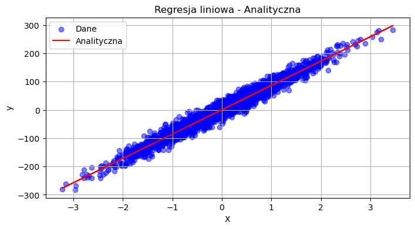

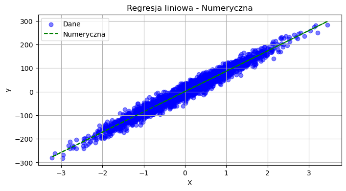

```python
plt.figure(figsize=(8, 4))
plt.scatter(X, y, color='blue', alpha=0.5, label='Dane')
plt.plot(X, alr_predictions, color='red', label='Analityczna')
plt.xlabel('X')
plt.ylabel('y')
plt.title('Regresja liniowa - Analityczna')
plt.legend()
plt.grid(True)
plt.show()

plt.figure(figsize=(8, 4))
plt.scatter(X, y, color='blue', alpha=0.5, label='Dane')
plt.plot(X, nlr_predictions, color='green', linestyle='--', label='Numeryczna')
plt.xlabel('X')
plt.ylabel('y')
plt.title('Regresja liniowa - Numeryczna')
plt.legend()
plt.grid(True)
plt.show()
```

### Wnioski

- Wykresy funkcji dla obu metod są praktycznie identyczne, gdyż parametry funkcji wychodzą podobne.
- Metoda analityczna może być szybsza dla mniejszego zbioru danych
- Metoda numeryczna może okazać się lepsza na bardziej skomplikowanych i większych zbiorów.

## 1.2 Porównanie *sklearn* oraz analitycznej implementacji regresji na zbiorze FlapPy Bird

```python
import numpy as np
import matplotlib.pyplot as plt
from sklearn.discriminant_analysis import StandardScaler
from sklearn.preprocessing import MinMaxScaler
from sklearn.linear_model import LinearRegression
from sklearn.preprocessing import PolynomialFeatures
from sklearn.metrics import mean_squared_error
import pandas as pd
```

#### Tworzenie zbiorów na podstawie danych z plików *.csv*

```python
## min road
min_data = pd.read_csv('min.csv', header=None)
X_min = min_data[0].values.reshape(-1, 1)
y_min = min_data[1].values
print(f"Zbiór minimalny: {len(X_min), len(y_min)} próbek.")

## full road
full_data = pd.read_csv('full_path.csv', header=None)
X_full = full_data[0].values.reshape(-1, 1)
y_full = full_data[1].values
print(f"Zbiór pełny: {len(X_full), len(y_full)} próbek.")

## key moments
X_key, y_key = [], []
last_y = None
for i, (x, y) in enumerate(zip(X_full.flatten(), y_full)):
    if y != last_y or (i > 0 and y_full[i-1] != y):
        X_key.append(x)
        y_key.append(y)
        last_y = y
X_key = np.array(X_key).reshape(-1, 1)
y_key = np.array(y_key)
print(f"Zbiór kluczowych: {len(X_key), len(y_key)} próbek.")
```

```
Zbiór minimalny: (71, 71) próbek.
Zbiór pełny: (1443, 1443) próbek.
Zbiór kluczowych: (297, 297) próbek.
```

Stworzone zostały trzy zbiory:

- **min_data** - zbiór zawierający jedynie punkty przelotu ptaka nad przeszkodą.
- **full_data** - zbiór zawierający wszystkie punkty przelotu ptaka.
- Na podstawie drugiego utworzony został zbiór kluczowych momentów **X/y_key**, który zawiera punkty zmian pozycji przelotu, czyli gdy ptak zmieniał wysokość swojego lotu.

#### Funkcje pomocnicze, które zostaną wykorzystane przy funkcjach do porównania modeli:

```python
def mse(w, X, y):
    X_bias = np.vstack([X, np.ones(len(X))]).T
    results = X_bias @ w

    return np.sum((y - results) ** 2) / len(y)

def normalize_data(X, y):
    ## Oblicza nową wartość z = (x - srednia) / odchylenie (średnia danej kolumny oraz odchylenie)
    scaler = StandardScaler()

    X_scaled = scaler.fit_transform(X)
    y_scaled = scaler.fit_transform(y.reshape(-1, 1)).flatten() ## StandardScaler działa na macierzy kolumnowej więc później przywracamy do pierwotnej wersji
    return X_scaled, y_scaled
```

#### Funkcja wykorzystująca gotowe metody z *sklearn*:

```python
def polynomial_regression(X, y, degree):
    X_scaled, y_scaled = normalize_data(X, y) ## Normalizacja danych

    poly = PolynomialFeatures(degree=degree)
    X_poly = poly.fit_transform(X_scaled) ## Przekształcenie danych do wersji wielomianowej

    model = LinearRegression()
    model.fit(X_poly, y_scaled) ## Trenowanie modelu LinearRegression

    predictions = model.predict(X_poly)

    mse = mean_squared_error(y_scaled, predictions) ## Wyznaczenie MSE

    return X_scaled, y_scaled, predictions, mse
```

#### Funkcja zawierająca własną implementację metody analitycznej do regresji wielomianowej:

```python
def analytical_regression(X, y, degree):
    X_scaled, y_scaled = normalize_data(X, y)

    X_poly = np.ones((len(X_scaled), degree + 1)) ## Macierz jedynek o długości stopnia wielomianu + 1
    for d in range(degree + 1):
        X_poly[:, d] = X_scaled.flatten() ** d ## Dla każdej kolumny (x^d) potęgujemy wartości x i wypełniamy macierz

    w = np.linalg.inv(X_poly.T @ X_poly) @ X_poly.T @ y_scaled ## Wynikiem jest wektor współczynników
    predictions = X_poly @ w

    mse = mean_squared_error(y_scaled, predictions)

    return X_scaled, y_scaled, predictions, mse
```

## **Wizualizacja wyników:**

```
Wielomian 9 stopnia
Zbiór: pełny
Wielkość zbioru: 1443
Błąd średniokwadratowy (analityczna): 0.2824659364387082
Błąd średniokwadratowy (sklearn): 0.28246593643870843
```

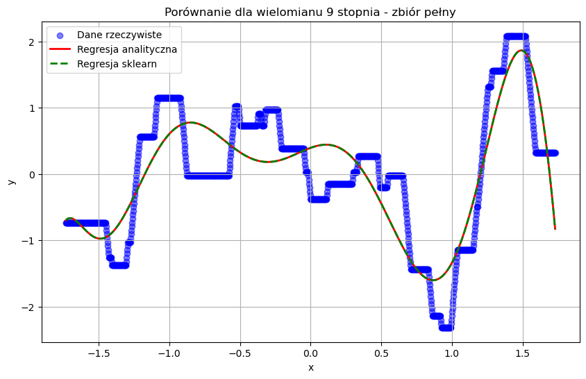

```
Wielomian 9 stopnia
Zbiór: kluczowych
Wielkość zbioru: 297
Błąd średniokwadratowy (analityczna): 0.12877200043266732
Błąd średniokwadratowy (sklearn): 0.12877200043266737
```

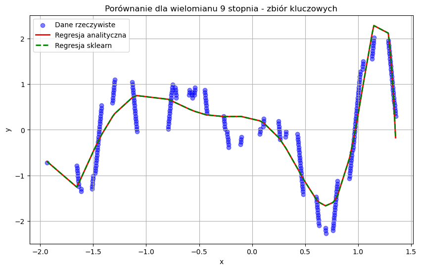

```
Wielomian 9 stopnia
Zbiór: minimalny
Wielkość zbioru: 71
Błąd średniokwadratowy (analityczna): 0.19416808937976152
Błąd średniokwadratowy (sklearn): 0.19416808937976196
```

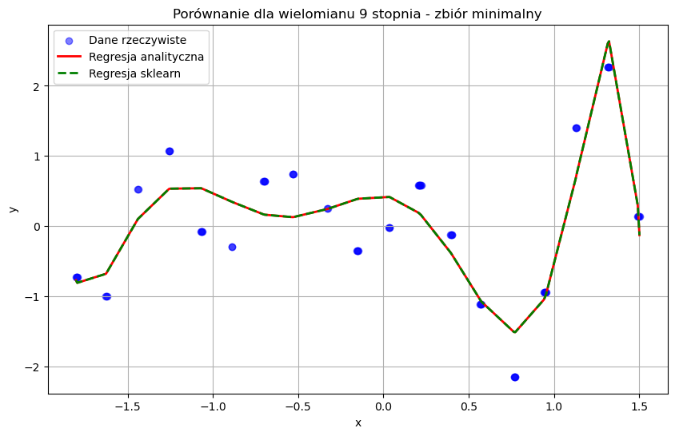

```
Wielomian 21 stopnia
Zbiór: pełny
Wielkość zbioru: 1443
Błąd średniokwadratowy (analityczna): 0.03999894886870045
Błąd średniokwadratowy (sklearn): 0.03999286837607337
```

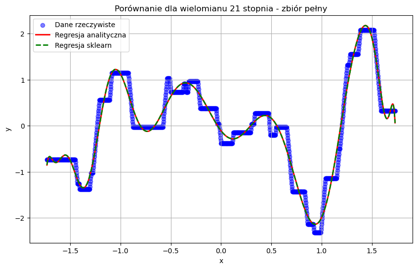

```
Wielomian 21 stopnia
Zbiór: kluczowych
Wielkość zbioru: 297
Błąd średniokwadratowy (analityczna): 0.047275400902774066
Błąd średniokwadratowy (sklearn): 0.03925494613232645
```

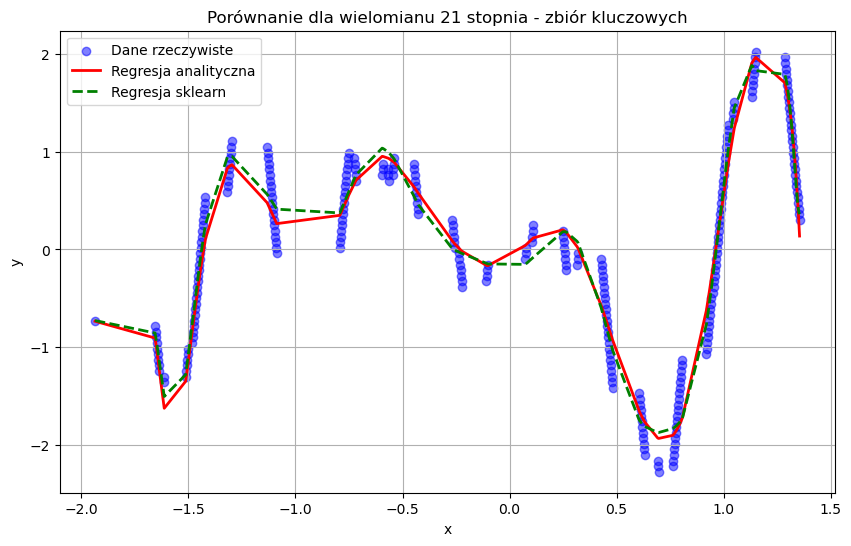

```
Wielomian 21 stopnia
Zbiór: minimalny
Wielkość zbioru: 71
Błąd średniokwadratowy (analityczna): 0.09132422010489154
Błąd średniokwadratowy (sklearn): 0.00044579106357288666
```

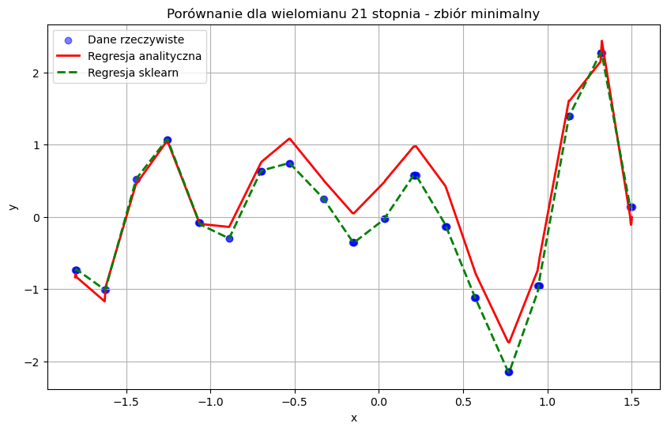

```python
degrees = [9, 21]
datasets = [
    {'name': 'pełny', 'data': (X_full, y_full)},
    {'name': 'kluczowych', 'data': (X_key, y_key)},
    {'name': 'minimalny', 'data': (X_min, y_min)}
]
results = []
for degree in degrees:
    for dataset in datasets:
        dataset_name = dataset['name']
        X, y = dataset['data']

        X1, y1, predictions_analytical, mse_analytical = analytical_regression(X, y, degree)
        X2, y2, predictions_polynomial, mse_polynomial = polynomial_regression(X, y, degree)

        results.append({
            'degree': degree,
            'dataset': dataset_name,
            'mse_analytical': mse_analytical,
            'mse_polynomial': mse_polynomial
        })

        print(f"Wielomian {degree} stopnia")
        print(f"Zbiór: {dataset_name}")
        print(f"Wielkość zbioru: {len(X)}")
        print(f"Błąd średniokwadratowy (analityczna): {mse_analytical}")
        print(f"Błąd średniokwadratowy (sklearn): {mse_polynomial}")

        plt.figure(figsize=(10, 6))
        plt.scatter(X1, y1, color='blue', label="Dane rzeczywiste", alpha=0.5)
        plt.plot(X1, predictions_analytical, color='red', label="Regresja analityczna", linewidth=2)
        plt.plot(X2, predictions_polynomial, color='green', label="Regresja sklearn", linewidth=2, linestyle='--')
        plt.xlabel("x")
        plt.ylabel("y")
        plt.legend()
        plt.title(f"Porównanie dla wielomianu {degree} stopnia - zbiór {dataset_name}")
        plt.grid(True)
        plt.show()
```